# POLI 572B

Michael Weaver

January 30, 2026

# Conditioning

### Objectives

1. $ACE$ without randomization
2. Confounding
   - DAGs
   - Dependence in Potential Outcomes
3. Conditioning
   - how it works (two approaches)
   - what not to do

# Example

So far, we have looked at **experiments**…

**What happens when we *don’t* have randomization**?

- some questions can’t be answered with survey experiments
- field experiments are expensive, hard to do
- randomization often impossible on important questions (cost/ethics)

In absence of randomization, how do we get unbiased estimates of $ACE$ or other causal estimands?

### An Example

**Contact Hypothesis**:

> Teach For America (TFA) is a prominent national service program that integrates top university graduates into low-income communities (often of color) for two years as teachers. Does service in TFA induce participants to harbor lower racial “resentment”?

[see here](https://doi.org/10.1017/S0003055418000412)

### An Example

**Contact Hypothesis**:

Imagine we **survey** and compare TFA **participants** and **non-participants** graduating from the same universities.

Measure “racial resentment” using a battery of questions (e.g. : “Racial discrimination in the US today limits the chances of individuals from [particular racial group] to get ahead?”).

Score $1$ to $5$, with $5$ being greatest resentment (“strongly disagree”), $1$ being least (“strongly agree”).

### An Example

Participating in Teach For America involves multiple stages of “selection”/“choice”:

- University graduates **choose** to apply.
- Teach For America **selects** candidates based on applicants.
- Selected candidates **choose** to accept or reject the offer.

How does this compare against assumptions made when analyzing experiments?

### An Example

We can imagine **potential outcomes**:

$i$ indexes individuals

$TFA_i$ indicates TFA participation ($1$) or not ($0$) of person $i$ ($D_i$)

$Y_i(0)$ is “racial resentment” without TFA participation

$Y_i(1)$ is “racial resentment” with TFA participation

### Potential Outcomes: TFA

| $i$ | $Y_i(0)$ | $Y_i(1)$ | $TFA_i$ |
| --- | --- | --- | --- |
| 1 | 2 | 1 | 1 |
| 2 | 2 | 1 | 1 |
| 3 | 3 | 1 | 1 |
| 4 | 2 | 1 | 0 |
| 5 | 3 | 1 | 0 |
| 6 | 3 | 1 | 0 |

What is the true $ACE$?

| $i$ | $Y_i(0)$ | $Y_i(1)$ | $TFA_i$ |
| --- | --- | --- | --- |
| 1 | 2 | 1 | 1 |
| 2 | 2 | 1 | 1 |
| 3 | 3 | 1 | 1 |
| 4 | 2 | 1 | 0 |
| 5 | 3 | 1 | 0 |
| 6 | 3 | 1 | 0 |

What is the estimate, $\widehat{ACE}$?, if we just compare mean racial resentment of TFA participants to non-participants?

| $i$ | $Y_i(0)$ | $Y_i(1)$ | $TFA_i$ |
| --- | --- | --- | --- |
| 1 | 2 | 1 | 1 |
| 2 | 2 | 1 | 1 |
| 3 | 3 | 1 | 1 |
| 4 | 2 | 1 | 0 |
| 5 | 3 | 1 | 0 |
| 6 | 3 | 1 | 0 |

```r
po.table = data.table(i = 1:6,
                      y_i_0 = c(2, 2, 3, 2, 3, 3),
                      y_i_1 = c(1, 1, 1, 1, 1, 1),
                      d_i = c(1,1,1,0,0,0)
                      )
#ace
ace = po.table[, y_i_1 - y_i_0] %>% mean

#ace_hat
ace_hat = po.table[, mean(y_i_1[(d_i)]) - mean(y_i_0[!(d_i)])]

ace
```

```
## [1] -1.5
```

```r
ace_hat
```

```
## [1] -1.666667
```

Because people select themselves into TFA, no randomization… if we reran this process again we would get the same result. **No alternate** allocations of TFA enrollment possible.

#### Why is the $\widehat{ACE} \$ biased?

# Confounding

### Confounding

**Confounding** occurs when, in the cases we observe, the values of treatment $D$ are **not independent** of potential outcomes of $Y$. Lead estimator $\widehat{ACE}$ to be **biased**

- Why might the potential outcomes of $Y$ (racial resentment) be **dependent** on the value of treatment ($TFA$)?

Non-independence of potential outcomes

| $i$ | $Y_i(0)$ | $Y_i(1)$ | $TFA_i$ |
| --- | --- | --- | --- |
| 1 | 2 | 1 | 1 |
| 2 | 2 | 1 | 1 |
| 3 | 3 | 1 | 1 |
| 4 | 2 | 1 | 0 |
| 5 | 3 | 1 | 0 |
| 6 | 3 | 1 | 0 |

### Confounding

- **Occurs usually when we don’t have randomization**
  - Note: $Z$ will be reserved for randomized variables; $D$ when randomization is unclear.
  - **size of bias** may vary, depending on extent of confounding
- **Can occur, despite randomization**
  - exclusion restriction violation
  - attrition
  - breaking experiment

### Confounding: Decomposition

Start with our “plug in” estimator of $ACE$:

$$E[\widehat{ACE}] = \overbrace{E[Y_i(1) |
D_i = 1 ]}^{\text{mean Y(1) in treated}} - \underbrace{E[Y_i(0) | D_i =
0]}_{\text{mean Y(0) in untreated}}$$

Add and subtract counterfactual $\color{red}{E[Y_i(0) | D_i = 1]}$

$$\begin{align*}
E[\widehat{ACE}] =& E[Y_i(1) | D_i = 1 ] - \color{red}{E[Y_i(0) |
D_i = 1]} \\
&+\color{red}{E[Y_i(0) | D_i = 1]} - E[Y_i(0) | D_i = 0]
\end{align*}$$

### Confounding

$$\begin{align*}
E[\widehat{ACE}] =& \overbrace{E[Y_i(1) | D_i = 1 ] -
\color{red}{E[Y_i(0) | D_i = 1]}}^{\text{ACE for treated (ATT)}} \\
&+ \underbrace{\color{red}{E[Y_i(0) | D_i = 1]} - E[Y_i(0) | D_i =
0]}_{\text{treated-untreated diff. in Y(0)}}
\end{align*}$$
If randomization… Is the top term different from ATU/ATC? What is the bottom term?

We need find substitution for $ATT$ in terms of $ACE$…

### Confounding

$$ACE = \pi ATT + (1 - \pi) ATU$$
$$ACE = \pi ATT + (1-\pi) ATT - (1-\pi)ATT +
(1 - \pi) ATU$$
$$ACE = [\pi +
(1-\pi)] ATT - (1-\pi)ATT + (1 - \pi) ATU$$
$$ACE = ATT - (1-\pi)(ATT - ATU)$$
$$ACE + (1-\pi)(ATT - ATU) = ATT$$

### Confounding

$$\begin{align*}
E[\widehat{ACE}] =& ATT \\
&+\color{red}{E[Y_i(0) | D_i = 1]} - E[Y_i(0) | D_i = 0]
\end{align*}$$

$$\begin{align*}
E[\widehat{ACE}] =& \overbrace{E[Y_i(1)] - E[Y_i(0)]}^{\text{ACE}} \
+ \\
& \overbrace{(1-\pi)(ATT - ATU)}^{\text{Heterogeneity Bias}} + \\
& \overbrace{\color{red}{E[Y_i(0) | D_i = 1]} - E[Y_i(0) | D_i =
0]}^{\text{Selection Bias}}
\end{align*}$$

### Confounding

**selection bias**: *baseline* differences in $Y(0)$ between “treated” and “untreated” units ($D=1$, $D=0$). Treated/untreated groups **already** different in absence of treatment.

**heterogeneity bias**: **effects** of treatment differ between “treated” and “untreated” units.

### Confounding

**Easier to understand confounding graphically**

- what it is, how it arises
- doesn’t distinguish between SOURCES of bias (selection/heterogeneity)

### Directed Acyclic Graphs (DAGs)

**DAGs**:

Graphs of *hypothesized* causal relationships between variables

- **nodes**/**vertices** represent variables in **causal chain** ($G$raph)
  - may be observed (filled) / unobserved (empty)
- **$D$irected arrows** represents flow of causality (not the magnitude/direction/functional form of effect)
- **no cycles**/$A$cyclic: variables cannot cause themselves (even indirectly)

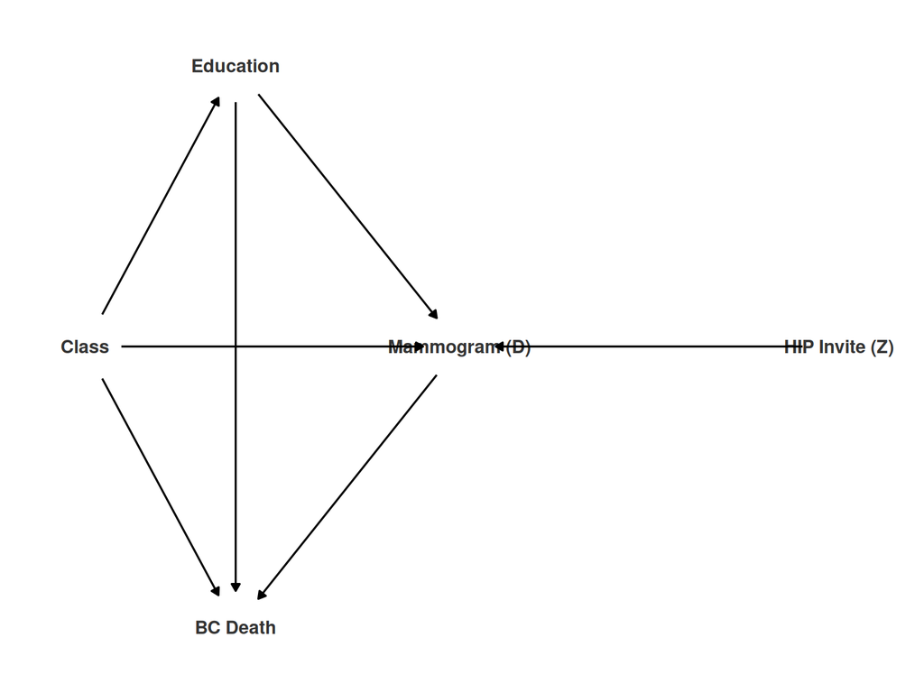

### Directed Acyclic Graphs (DAGs)

Using a **DAG**:

**Confounding** exists when there is a **backdoor path** between variable of interest $D$ and the outcome $Y$.

A **backdoor path** is a **non-causal** path from $D$ to $Y$:

- a path that remains after we remove arrows point outward from $D$
- that only *changes direction once* (backwards from $D$, forwards to $Y$)
- “backdoor” because it follows arrows backwards out of $D$

What are the backdoor paths for “Mammogram”?

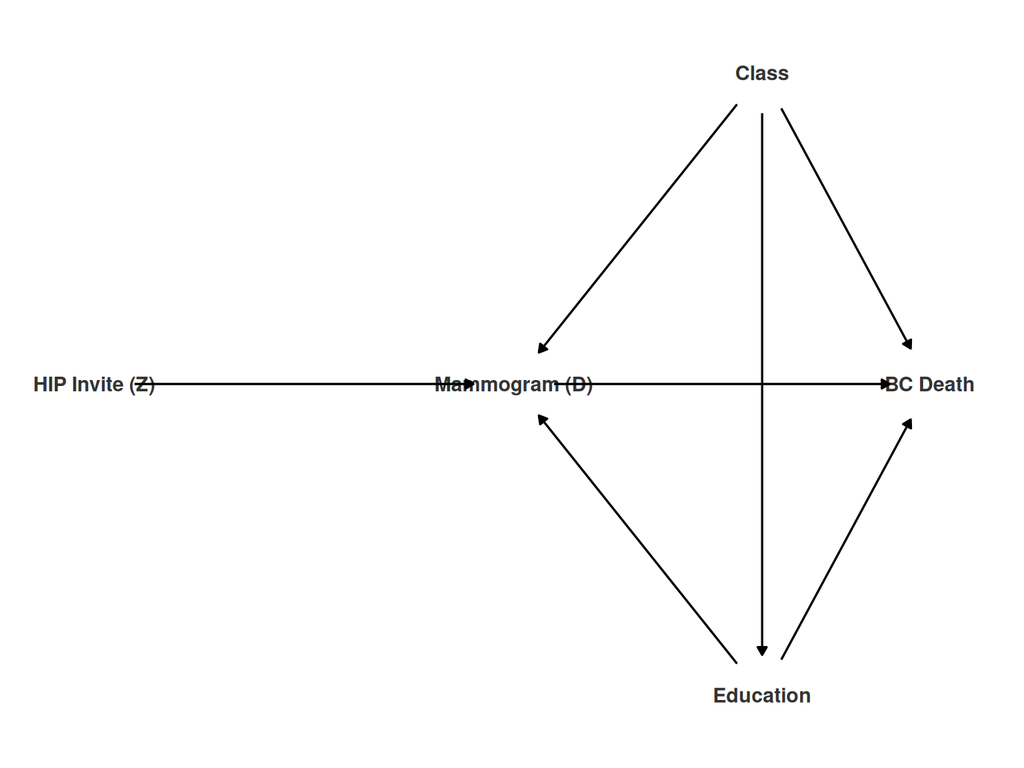

### Directed Acyclic Graphs (DAGs)

The “backdoor” criterion for confounding points to solutions:

1. Find a causal variable that has no backdoor paths:
   - randomization is only way to be sure: $Z$ as “instrument”

Using the $CACE$ in an Experiment

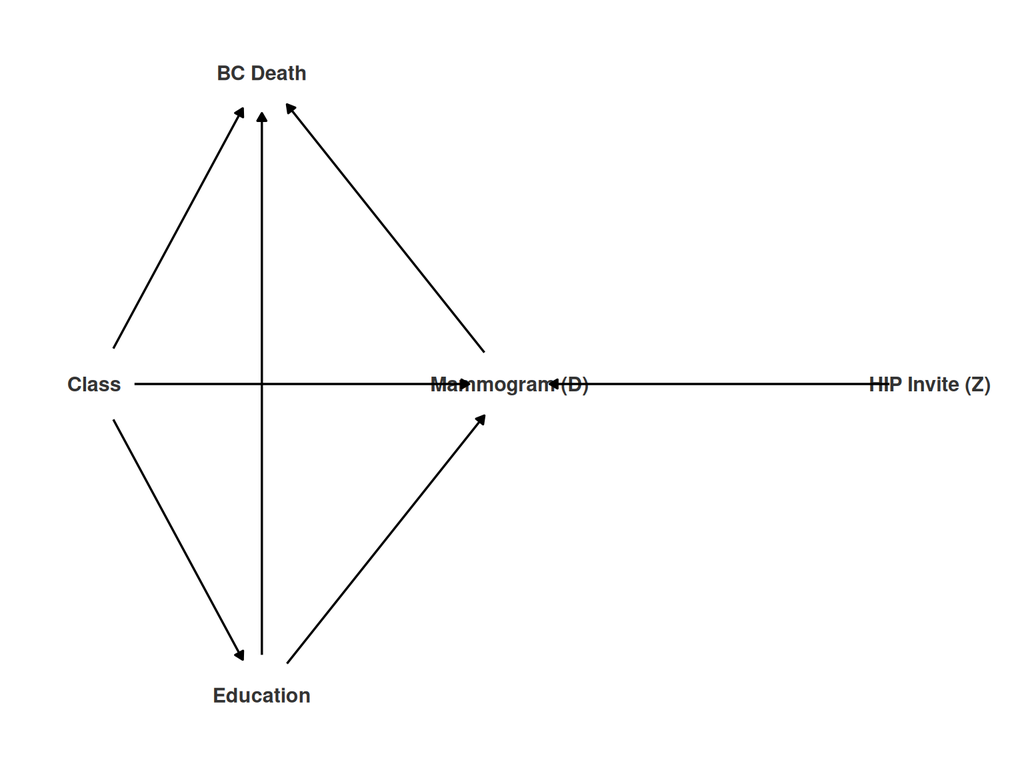

[Miguel et al 2004](https://www.journals.uchicago.edu/doi/10.1086/421174)

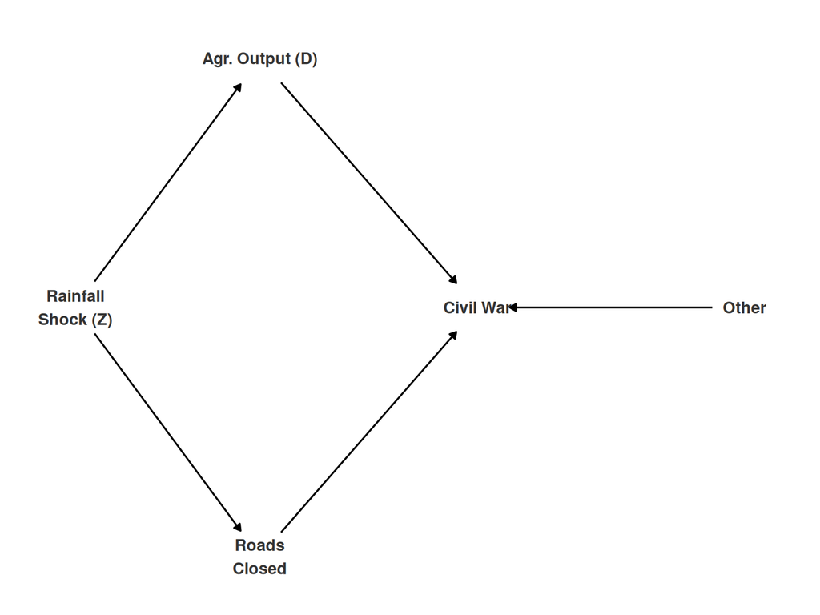

Exclusion Restriction Violation in $CACE$ [Miguel et al 2004](https://www.journals.uchicago.edu/doi/10.1086/421174)

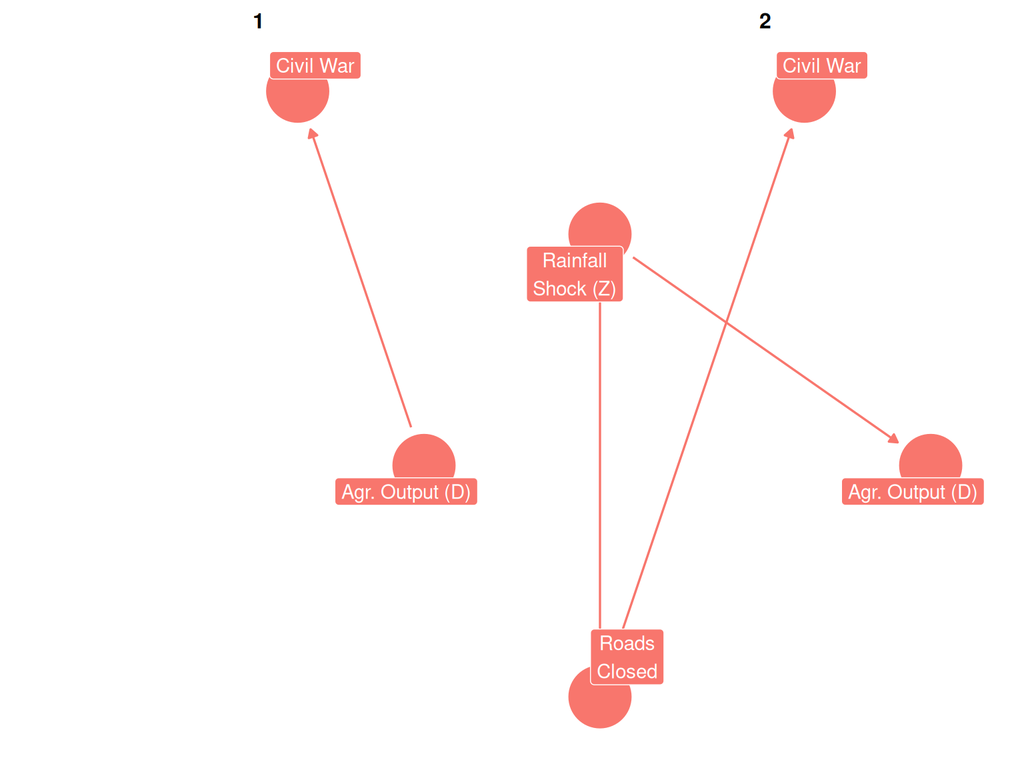

### Directed Acyclic Graphs (DAGs)

What if we don’t have randomization?

In groups: Create a DAG for the TFA.

- what are $3$ variables that might **affect joining TFA**?
- For each of these, identify $1$ possible cause of that variable
- For every variable (max 6) you came up with, could it directly/indirectly **affect racial resentment**?
- Draw a DAG corresponding to these connections on the white board.
- Other solutions to confounding?

### Directed Acyclic Graphs (DAGs)

The “backdoor” criterion for confounding points to solutions:

1. Find a causal variable that has no backdoor paths:
- randomization is only way to be sure
2. “Block” backdoor paths by “holding variables constant”: **conditioning**

### Conditioning:

**conditioning** is when we compare values of $Y_i$ across values of $D_i$ (e.g. TFA) using information on the values of other variables $\mathbf{X_i}$,

- Where $\mathbf{X_i}$ is a set of variables (we suspect) appear on backdoor paths from $D$ to $Y$.
- We use values of $\mathbf{X_i}$ to:
  - **impute** missing counterfactual values of $Y_i$ across values of $D_i$ (within strata) where values of $\mathbf{X_i}$ are the same
  - (and/or) **reweight**: compare values of $Y_i$ across values of $D_i$, **weighting** $i$ by probability of “treatment” given $\mathbf{X_i}$ ($Pr(D_i | X_i)$)

Result is **blocking** backdoor (non-causal) paths from $D$ to $Y$.

### Directed Acyclic Graphs (DAGs)

Want to **Condition on** variables that

- have causal paths toward $D$ and toward $Y$ **or**
- have causal paths toward $Y$ and backdoor path to $D$

Are there variables we **should NOT condition on?**

If we want to find the effect of ability on earnings (but we don’t directly observe ability, only exam scores): what variables should we condition on?

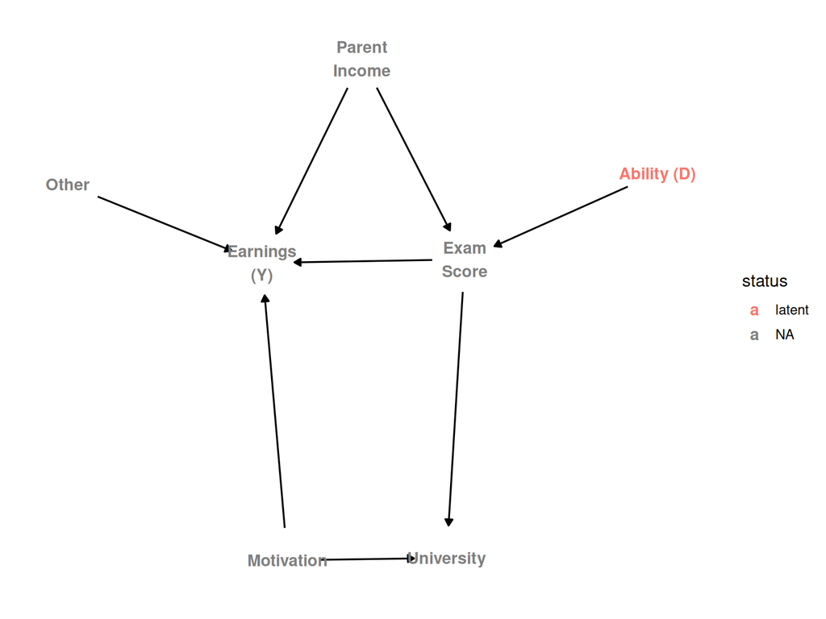

Should we condition on University admissions? DAG says it doesn’t affect earnings, but in the real world, we might consider that a possibility…

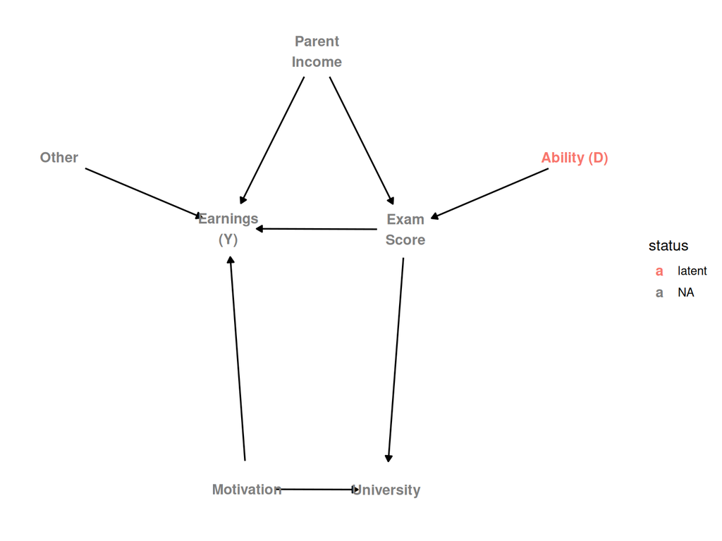

### Consider University Admissions:

Admission might be a function of

- Motivation
- Academic Ability (as measured by exam scores)
- Assume (as in the DAG) that motivation and academic ability are **independent** of each other

What happens when we examine the relationship between motivation and academic ability among groups where university admissions are held constant?

(board)

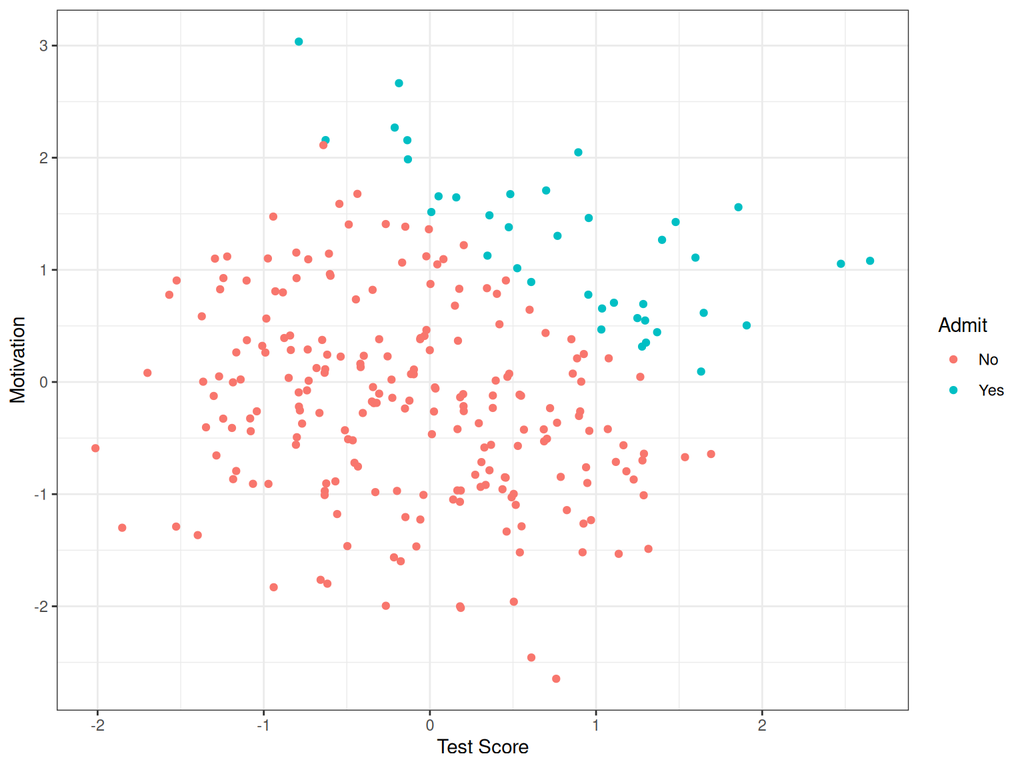

**Within strata defined by admission status**, ability and motivation are **no longer independent**.

### Directed Acyclic Graphs (DAGs)

We may be tempted to condition on as many variables as possible, but this can lead to trouble!

**colliders**: variables that are causally influenced by two or more variables (2+ arrows pointing into it). The causal variables influencing the collider are themselves not necessarily associated.

- **conditioning** on the **collider** can INDUCE associations between variables that were not associated.
- typically (not always) due to conditioning on **post-treatment** variable

### Directed Acyclic Graphs (DAGs)

We may be tempted to condition on as many variables as possible, but this can lead to trouble!

**mediators**: variables that are on the path from $D$ to $Y$ (“how” $D$ affects $Y$)

- **conditioning** on a **mediator** $M$: possibly a collider (other things affect $M$); “blocks” path from $D$ to $Y$

### Directed Acyclic Graphs (DAGs)

**Condition on** all variables that

- have causal paths toward $D$ and toward $Y$ **or**
- have causal paths toward $Y$ and backdoor path to $D$

**Do NOT condition** on variables that

- **are on causal path** from $D$ to $Y$ (mediators)
- **are “colliders”** connected to backdoor paths

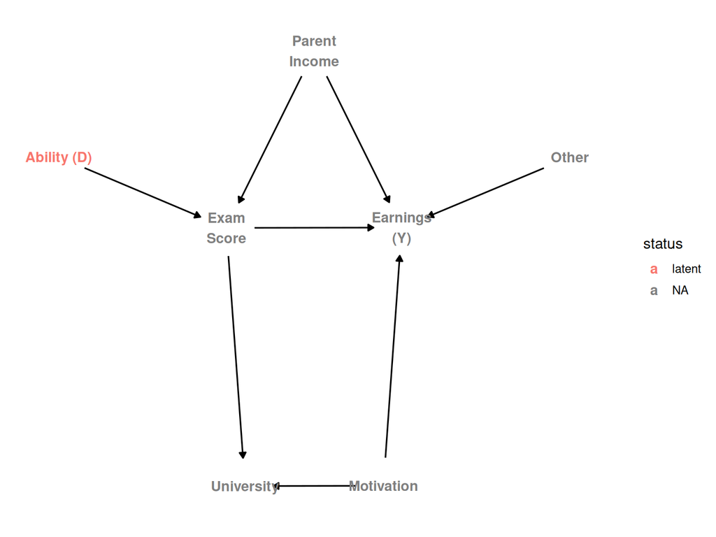

### Directed Acyclic Graphs (DAGs)

To find effect of ability (through exam scores) on income, should condition on:

- Parent Income (close back door path)
- NOT University (a collider: opens backdoor path from motivation to earnings.)

### Colliders

When does collider bias arise?

- Can happen in a variety of circumstances, but is VERY COMMON for variables that are “post-treatment” (to the board)
- See Morgan and Winship, Chapter 4

### Directed Acyclic Graphs (DAGs)

1. **Condition on** variables that
- **have causal paths toward $D$ and toward $Y$**
- have causal paths toward $Y$ and backward path toward $D$
2. **Do NOT condition on** variables that
- **are on causal path** from $D$ to $Y$ (**mediators**)
- **are “colliders”**
3. Best practice:
- **Condition on variables that have causal paths toward $D$ and $Y$**: “pre-treatment”
- DAGs are hypothetical, “severity” suggests we consider all **plausible** DAGs, results should be robust to choices

### Directed Acyclic Graphs (DAGs)

**As a class**:

Revisit our TFA DAGs:

**Identify variables we need to condition on to close backdoor paths** and find effect of TFA on racial resentment

### Directed Acyclic Graphs (DAGs)

#### Pros:

- Can help us be **explicit** about our assumptions (what backdoor paths or colliders can/cannot exist)

Given an **assumed** DAG…

- Can tell us when conditioning can/cannot block backdoor paths
- Can tell us what to condition on/ not to condition on
- Software to figure out complex situations

#### Cons:

- DAGs are assumed, never really known
- How to make logic of DAGs compatible with **weak severity**?

# Conditioning

In order for conditioning to estimate the $ACE$ without bias, we must assume

$1$. **Ignorability**/**Conditional Independence**: within strata of $X$, potential outcomes of $Y$ must be **independent** of $D$ (i.e. for cases with same values of $X$, $D$ must be as-if random)

- all ‘backdoor’ **paths** are blocked
- no conditioning on colliders to ‘unblock’ backdoor path
- Connects to how **imputation** and **reweighting** work

In order for conditioning to estimate the $ACE$ without bias, we must assume

$2$. **Positivity**/**Common Support**: For **all** values of treatment $d$ in $D$ and all value of $x$ in $X$: $Pr(D = d | X = x) > 0$ and $Pr(D = d | X = x) < 1$

- There must be variation in the levels of treatment **within every strata** of $X$
- If not, we can get other **causal estimands** but not $ACE$

In order for conditioning to estimate the $ACE$ without bias, we must assume

3. **No Measurement Error**: If conditioning variables $X$ are mismeasured, bias will persist.
- If substantial measurement error, backdoor paths not blocked
- Even random measurement error in $X$ a problem

### Two Ways of Conditioning:

- **imputation**/**matching**: “plug in” unobserved potential outcomes of $\color{red}{Y_i(1)}$ ($\color{red}{Y_i(0)}$) using observed potential outcomes of $Y_j(1)$($Y_j(0)$) from cases with **same**/**similar** values of $\mathbf{X_i} \cong \mathbf{X_j}$.
- **reweighting**: re-weight members of “treated” and “untreated” groups based on $Pr(D_i | \mathbf{X_i})$

Both implicitly assume that, for cases with same values in conditioning variables $\mathbf{X_i}$, $D_i$ is effectively “as-if” random

### Conditioning by Imputation

**Conditioning** with imputation contrasts to calculating **naive** $\widehat{ACE}$:

Rather than taking this difference:

$\widehat{ACE} = E[Y(1) | D = 1] - E[Y(0) | D=0]$

which may be biased… $ACE \neq E[\widehat{ACE}]$

### Conditioning by Imputation

Instead, we find effect of $D$ on $Y$ within each subset of the data with same values of $X_i$.

$\widehat{ACE}[X_i = x] = E[Y_i(1) | D_i=1, X_i = x] - E[Y_i(0) | D_i = 0, X_i = x]$

for **all** unique set of values of $x$ in the data.

### Conditioning by Imputation

Under the Conditional Independence Assumption,

$\overbrace{E[Y_i(1) | D_i=1, X_i=x]}_{\text{among treated cases w/ value of X}} = \underbrace{\color{red}{E[Y_i(1) | D_i=0, X_i=x]}}^{\text{among untreated cases w/ value of X} }$

and $E[Y_i(0) | D_i=0, X_i=x] = \color{red}{E[Y_i(0) | D_i=1, X_i=x]}$

In short, CIA $\to$ we assume that with $X$ held constant, like drawing $Y_(1)$ and $Y_i(0)$ at random (VERY IMPORTANT, re: sampling distribution of conditioning estimators)

Then take a **weighted average** of all $\widehat{ACE}[X_i = x]$, weighted by $Pr(X_i = x)$ (fraction of cases where $X_i = x$)

$$\widehat{ACE} = \sum\limits_{x}
\widehat{ACE}[X = x]Pr(X=x)$$

### Conditioning by Imputation

Why is this **imputation**?

We’re **imputing**/**plugging in** $\color{red}{unobserved}$ potential outcomes using $observed$ potential outcomes.

### Conditioning: Example

Imagine we have our binary treatment $TFA_i$ and we want to know its average effect on $Y_i$, racial resentment.

But we lack random assignment; possible selection bias ($Y_i(0)$ already different for joiners and heterogeneity bias (effect of $TFA$ different for joiners).

We think that this dependence is induced by majoring in economics ($X_i$), which affects $TFA_i$ and $Y_i$.

We solve this problem with conditioning.

Economists

[figure not shown]

Example (1)

| $i$ | $Y_i(0)$ | $Y_i(1)$ | $TFA_i$ | $X_i$ |
| --- | --- | --- | --- | --- |
| 1 | 2 | 1 | 1 | 0 |
| 2 | 2 | 1 | 1 | 0 |
| 3 | 3 | 1 | 1 | 1 |
| 4 | 2 | 1 | 0 | 0 |
| 5 | 3 | 1 | 0 | 1 |
| 6 | 3 | 1 | 0 | 1 |

Example (1): Let’s “condition” on $X$

| $i$ | $Y_i(0)$ | $Y_i(1)$ | $TFA_i$ | $X_i$ | $Y_i$ |
| --- | --- | --- | --- | --- | --- |
| 4 | 2 | 1 | 0 | 0 | 2 |
| 1 | 2 | 1 | 1 | 0 | 1 |
| 2 | 2 | 1 | 1 | 0 | 1 |
| 5 | 3 | 1 | 0 | 1 | 3 |
| 6 | 3 | 1 | 0 | 1 | 3 |
| 3 | 3 | 1 | 1 | 1 | 1 |

Calculate $\widehat{ACE}$ using conditioning

Example (1): Conditioning in `R`

```r
#ACE | X = 0
ace_x0 = po.table[x_i %in% 0, mean(y_i[d_i == 1]) - mean(y_i[d_i == 0])]
#ACE | X = 1
ace_x1 = po.table[x_i %in% 1, mean(y_i[d_i == 1]) - mean(y_i[d_i == 0])]
#Ace Hat
mean(c(ace_x0, ace_x1))
```

```
## [1] -1.5
```

```r
#Ace
ace
```

```
## [1] -1.5
```

- Why does conditioning recover the true $ACE$?

Example (2) Let’s “condition” on $X$

| $i$ | $Y_i(0)$ | $Y_i(1)$ | $TFA_i$ | $X_i$ | $Y_i$ |
| --- | --- | --- | --- | --- | --- |
| 4 | 2 | 1 | 0 | 0 | 2 |
| 1 | 2 | 1 | 1 | 0 | 1 |
| 2 | 2 | 1 | 1 | 0 | 1 |
| 5 | 3 | 1 | 0 | 1 | 3 |
| 6 | 3 | 3 | 0 | 1 | 3 |
| 3 | 3 | 1 | 1 | 1 | 1 |

Calculate $\widehat{ACE}$ using conditioning

Example (2): Conditioning in `R`

```r
ace_x0 = po.table[x_i %in% 0, mean(y_i[d_i == 1]) - mean(y_i[d_i == 0])]

ace_x1 = po.table[x_i %in% 1, mean(y_i[d_i == 1]) - mean(y_i[d_i == 0])]

#Ace HAT
mean(c(ace_x0, ace_x1))
```

```
## [1] -1.5
```

```r
#Ace
ace
```

```
## [1] -1.166667
```

- Why does $\widehat{ACE} \neq ACE$ in this case?

Example (3)

| $i$ | $Y_i(0)$ | $Y_i(1)$ | $TFA_i$ | $X_i$ | $Y_i$ |
| --- | --- | --- | --- | --- | --- |
| 4 | 2 | 1 | 0 | 0 | 2 |
| 1 | 2 | 1 | 1 | 0 | 1 |
| 2 | 2 | 1 | 1 | 0 | 1 |
| 5 | 3 | 1 | 0 | 1 | 3 |
| 3 | 3 | 1 | 1 | 1 | 1 |

Calculate $\widehat{ACE}$ using conditioning

Example (3): Conditioning in `R`

```r
#ACE | X = 0
ace_x0 = po.table[x_i %in% 0, mean(y_i[d_i == 1]) - mean(y_i[d_i == 0])]
#ACE | X = 1
ace_x1 = po.table[x_i %in% 1, mean(y_i[d_i == 1]) - mean(y_i[d_i == 0])]
#Ace Hat
mean(c(ace_x0, ace_x1))
```

```
## [1] -1.5
```

```r
#Ace
ace
```

```
## [1] -1.4
```

- Why does $\widehat{ACE} \neq ACE$ in this case?

Example (3): Conditioning in `R`

```r
#ACE | X = 0
ace_x0 = po.table[x_i %in% 0, mean(y_i[d_i == 1]) - mean(y_i[d_i == 0])]
#ACE | X = 1
ace_x1 = po.table[x_i %in% 1, mean(y_i[d_i == 1]) - mean(y_i[d_i == 0])]
#Ace Hat: weighting by size of each group in X
weighted.mean(c(ace_x0, ace_x1), w = c(3,2))
```

```
## [1] -1.4
```

```r
#Ace
ace
```

```
## [1] -1.4
```

- Why does $\widehat{ACE} == ACE$ in this case?
- We correctly weight by $Pr(X = x)$

Example (4): Condition on $X$

| $i$ | $Y_i(0)$ | $Y_i(1)$ | $TFA_i$ | $X_i$ | $Y_i$ |
| --- | --- | --- | --- | --- | --- |
| 8 | 1 | 1 | 1 | -1 | 1 |
| 4 | 2 | 1 | 0 | 0 | 2 |
| 1 | 2 | 1 | 1 | 0 | 1 |
| 2 | 2 | 1 | 1 | 0 | 1 |
| 5 | 3 | 1 | 0 | 1 | 3 |
| 6 | 3 | 1 | 0 | 1 | 3 |
| 3 | 3 | 1 | 1 | 1 | 1 |
| 7 | 5 | 4 | 0 | 2 | 5 |

Can we use conditioning to recover the $ACE$?

### Example (4)

Why can’t conditioning recover the true $ACE$?

### Conditioning by Imputation

1. **Ignorability**/**Conditional Independence**:
   - violated in Example 2
2. **Positivity**/**Common Support**:
   - violated in Example 4

### Conditioning: Limitations

1. **Ignorability**/**Conditional Independence**:
   - an untestable assumption: there may be unobserved variables we should condition on
   - can argue this is plausible using theory/knowledge of cases; or argue for partial identification
2. **Positivity**/**Common Support**:
   - with more conditioning variables: less likely positivity is to hold
   - many unique combinations of $X$ with little variation in $D$ (curse of dimensionality)
3. **Measurement Error**:
   - This exacerbates problems with assumption (1)

### Conditioning: Assumptions

**Positivity**/**Common Support**: Without positivity, $\widehat{ACE}$ may be biased, but can estimate other causal parameters:

- $ATT$: Average Treatment effect on Treated:
  - requires positivity **only for values of $x$ held by units in treatment**
- $ATC$: Average Treatment effect on Control
  - requires positivity **only for values of $x$ held by units in control**
- Treatment effects for strata with **positivity**
  - requires thinking about interpretation (like $CACE$, for whom does effect hold?)

### Conditioning by Imputation: Approaches

1. Matching: (**exact** matching is what we’ve been doing, other types)
2. Regression: (interpolate values of $Y$ as **linear** and **additive** in $X$)
3. Machine Learning: (impute predicted values of $Y$ using statistical learners)

### Conditioning by Reweighting

Another way of conditioning focuses on the **selection** into treatment $D$, rather than imputing potential outcomes of $Y$.

### Conditioning by Reweighting

If there is confounding, then the observed values of $Y(1)$ are systematically different than $E[Y_i(1)]$ for all of the cases (bias). Why? (board)

If we knew **the probability each case was treated** ($Pr(D_i)$) then we can **re-weight** observed values of $Y(1)$ such that we **reconstruct** the $E[Y(1)]$. The same can be done for $Y(0)$

TO THE BOARD

### Conditioning by Reweighting

Under the conditional independence assumption, $Pr(D | X = x)$ is the same for all cases $X = x$, and adjusting for the probability of treatment $D$, potential outcomes of $Y$ are independent of $D$

- holding $X = x$, like assigning treatment at random, with probability $p$

$Pr(D | X = x)$ is called the **propensity score**, which we can estimate.

### Conditioning by Reweighting

This approach leads us to the inverse probability weighting estimator of the $ACE$:

$$\widehat{ACE} =
\frac{1}{N}\sum\limits_{i=1}^N
\frac{D_iY_i}{\widehat{Pr}(D_i|\mathbf{X_i})}-\frac{(1-D_i)Y_i}{1-\widehat{Pr}(D_i|\mathbf{X_i})}$$

Example (1): Let’s “condition” on $X$

| $i$ | $Y_i(0)$ | $Y_i(1)$ | $TFA_i$ | $X_i$ | $Y_i$ |
| --- | --- | --- | --- | --- | --- |
| 8 | 2 | 1 | 0 | 0 | 2 |
| 5 | 2 | 1 | 1 | 0 | 1 |
| 6 | 2 | 1 | 1 | 0 | 1 |
| 7 | 2 | 1 | 1 | 0 | 1 |
| 1 | 3 | 1 | 0 | 1 | 3 |
| 2 | 3 | 1 | 0 | 1 | 3 |
| 3 | 3 | 1 | 0 | 1 | 3 |
| 4 | 3 | 1 | 1 | 1 | 1 |

### Conditioning by Reweighting:

1. Estimate Propensity Scores: known probabilities, logit regression, machine learning, balancing weights
- different ways to get treatment probabilities (assuming conditional independence)
2. Estimate $ACE$ with inverse probability weighting
- different choices of weight calculations

### Conditioning: Why not use both?

We can use both **imputation** *and* **re-weighting** at the same time. This is called “doubly robust” estimation, as it can give us an unbiased estimate of the $ACE$ if either the imputation model or the propensity score model is correct.

### Conditioning:

In absence of randomization, we condition (by imputation or reweighting). We always assume:

1. **Ignorability**/**Conditional Independence**
2. **Positivity**/**Common Support**

Different methods of conditioning may make additional assumptions. We need to be aware and evaluate their plausibility.